# EP09-respuesta-equipo-2

2026-01-07

## Pregunta 1

Definir la semilla a utilizar, que corresponde a los últimos cuatro dígitos del RUN (sin considerar el dígito verificador) del integrante de menor edad del equipo.

```r
library(car)
library(leaps)
library(dplyr)
library(rsample)
datos <- read.csv2("EP09 Datos.csv")
# 21823234-5
set.seed(3234)

mujeres <- datos |>
  filter(datos$Gender == 0)
```

## Pregunta 2

Seleccionar una muestra aleatoria de 100 mujeres (si la semilla es un número par) o 100 hombres (si la semilla es impar), y separar 70 casos para trabajar en la construcción de modelos y 30 para su evaluación en datos no vistos.

```r
# Como la semilla es un número par

#Se seleccionan 100 mujeres aleatorias
mujeres_random <- mujeres |>
  sample_n(100)

#Se seleccionan 70 casos para la construcción de modelos
mujeres_random70 <- mujeres_random |>
  sample_n(70)
mujeres_random_30 <- mujeres_random |>
  anti_join(mujeres_random70)
```

[output not shown]

```r
#Se saca del dataframe las variables que no seran variables predictoras
mujeres_filtrado <- mujeres_random |>
  select(-Height,-Weight,-Gender)
```

## Pregunta 3

Seleccionar de forma aleatoria ocho posibles variables predictoras.

```r
#Nombre de las columnas
columnas_raw <- names(mujeres_filtrado)
columnas <- data.frame(columnas_raw)

#Se seleccionan de forma aleatoria 8 variables predictoras
variables_aleatorias <- columnas |>
  sample_n(8)

#Nombre variables predictoras
names_raw <- variables_aleatorias$columnas_raw
print(names_raw)
```

```
## [1] "Chest.depth"         "Ankle.Minimum.Girth" "Wrist.Minimum.Girth"
## [4] "Age"                 "Shoulder.Girth"      "Thigh.Girth"
## [7] "Calf.Maximum.Girth"  "Waist.Girth"
```

Las variables aleatorias escogidas son:

```r
library("DT")
Descripcion  = c("Grosor del pecho, sobre tejido mamario en mujeres y a la altura de los pezones en varones","Grosor promedio de la parte más delgada de ambos tobillos", "Grosor promedio de la parte más delgada de ambas muñecas", "Edad", "Grosor de los hombros sobre los músculos deltoides", "Grosor promedio de ambos muslos bajo el pliegue del glúteo", "Grosor promedio de la parte más ancha de ambas pantorrillas", "Grosor a la altura de la cintura") #Descripción de cada componente

Unidad = c("cm", "cm", "cm", "Años", "cm", "cm", "cm", "cm")

#Tipos de variables correspondientes a los componentes
#Tabla recopilando los datos anteriores
Tabla_variables = data.frame(names_raw,Descripcion,Unidad)
datatable(Tabla_variables,
          options = list(pageLength = 14),
          caption = "Tabla de descripción de variables aleatorias")
```

|  | names_raw | Descripcion | Unidad |
| --- | --- | --- | --- |
| 1 | Chest.depth | Grosor del pecho, sobre tejido mamario en mujeres y a la altura de los pezones en varones | cm |
| 2 | Ankle.Minimum.Girth | Grosor promedio de la parte más delgada de ambos tobillos | cm |
| 3 | Wrist.Minimum.Girth | Grosor promedio de la parte más delgada de ambas muñecas | cm |
| 4 | Age | Edad | Años |
| 5 | Shoulder.Girth | Grosor de los hombros sobre los músculos deltoides | cm |
| 6 | Thigh.Girth | Grosor promedio de ambos muslos bajo el pliegue del glúteo | cm |
| 7 | Calf.Maximum.Girth | Grosor promedio de la parte más ancha de ambas pantorrillas | cm |
| 8 | Waist.Girth | Grosor a la altura de la cintura | cm |

## Pregunta 4

```r
#Dataframe sin las variables de altura ni genero
mujeres_filtrado_con_peso <- mujeres_random70 |>
  select(-Height,-Gender)

#Se quitan las 8 variables predictoras seleccionadas anteriormente
mujeres_seleccion <- mujeres_filtrado_con_peso |>
  select(-all_of(names_raw))

# Generamos un modelo nulo del peso para poder agregar variables
peso_nulo <- lm(Weight ~ 1, mujeres_seleccion)
completo <- lm(Weight ~ ., mujeres_seleccion)
summary(peso_nulo)
```

```
##
## Call:
## lm(formula = Weight ~ 1, data = mujeres_seleccion)
##
## Residuals:
##     Min      1Q  Median      3Q     Max
## -14.934  -5.884  -1.534   6.566  21.066
##
## Coefficients:
##             Estimate Std. Error t value Pr(>|t|)
## (Intercept)   60.734      1.056    57.5   <2e-16 ***
## ---
## Signif. codes:  0 '***' 0.001 '**' 0.01 '*' 0.05 '.' 0.1 ' ' 1
##
## Residual standard error: 8.837 on 69 degrees of freedom
```

### Elección del predictor

```r
paso <- add1(
  peso_nulo,
  scope = completo,
  test = "F"
) |>
  as.data.frame() |>
  tibble::rownames_to_column("variable") |>
  arrange(AIC)

paso
```

```
##                   variable Df Sum of Sq      RSS      AIC   F value
## 1                Hip.Girth  1  4285.742 1102.315 196.9671 264.38031
## 2              Navel.Girth  1  3805.187 1582.870 222.2950 163.47057
## 3              Chest.Girth  1  3683.810 1704.248 227.4669 146.98514
## 4              Bicep.Girth  1  3633.544 1754.514 229.5016 140.82586
## 5            Forearm.Girth  1  3338.822 2049.235 240.3709 110.79250
## 6               Knee.Girth  1  3166.852 2221.206 246.0117  96.94998
## 7           Chest.diameter  1  2260.947 3127.111 269.9559  49.16500
## 8           Knees.diameter  1  2254.877 3133.181 270.0916  48.93800
## 9          Ankles.diameter  1  1856.194 3531.863 278.4760  35.73785
## 10 Bitrochanteric.diameter  1  1746.352 3641.706 280.6199  32.60887
## 11        Biiliac.diameter  1  1560.932 3827.126 284.0962  27.73449
## 12         Elbows.diameter  1  1486.866 3901.192 285.4380  25.91692
## 13         Wrists.diameter  1  1404.778 3983.279 286.8956  23.98148
## 14     Biacromial.diameter  1  1034.224 4353.834 293.1222  16.15294
```

[output cut: 17 more lines]

## Pregunta 5

Usando el entorno R y paquetes estándares, construir un modelo de regresión lineal simple con el predictor seleccionado en el paso anterior.

Recordando que las hipótesis en el modelo de regresión lineal son:
$$H_{0}: \beta_{1} = 0$$
$$H_{A}: \beta_{1} \neq 0$$
Donde $\beta_{1}$ es la pendiente del modelo, $\beta_{0}$ la intersección con el eje $y$ y $x$ la variable predictora (en este caso Hip.Girth).
$$\hat{y} = \beta_{0} +
\beta_{1}x$$

El predictor seleccionado fue “Hip.Girth” por lo tanto se construye el modelo agregando esta variable al modelo nulo.

```r
modelo_HG <- update(peso_nulo, . ~ . + Hip.Girth)
summary(modelo_HG)
```

```
##
## Call:
## lm(formula = Weight ~ Hip.Girth, data = mujeres_seleccion)
##
## Residuals:
##     Min      1Q  Median      3Q     Max
## -7.0076 -2.6557 -0.8502  2.2600 11.6888
##
## Coefficients:
##             Estimate Std. Error t value Pr(>|t|)
## (Intercept) -51.3978     6.9131  -7.435 2.32e-10 ***
## Hip.Girth     1.1740     0.0722  16.260  < 2e-16 ***
## ---
## Signif. codes:  0 '***' 0.001 '**' 0.01 '*' 0.05 '.' 0.1 ' ' 1
##
## Residual standard error: 4.026 on 68 degrees of freedom
## Multiple R-squared:  0.7954, Adjusted R-squared:  0.7924
## F-statistic: 264.4 on 1 and 68 DF,  p-value: < 2.2e-16
```

Se arma un gráfico para visualizar el modelo construido.

```r
library (ggpubr)
```

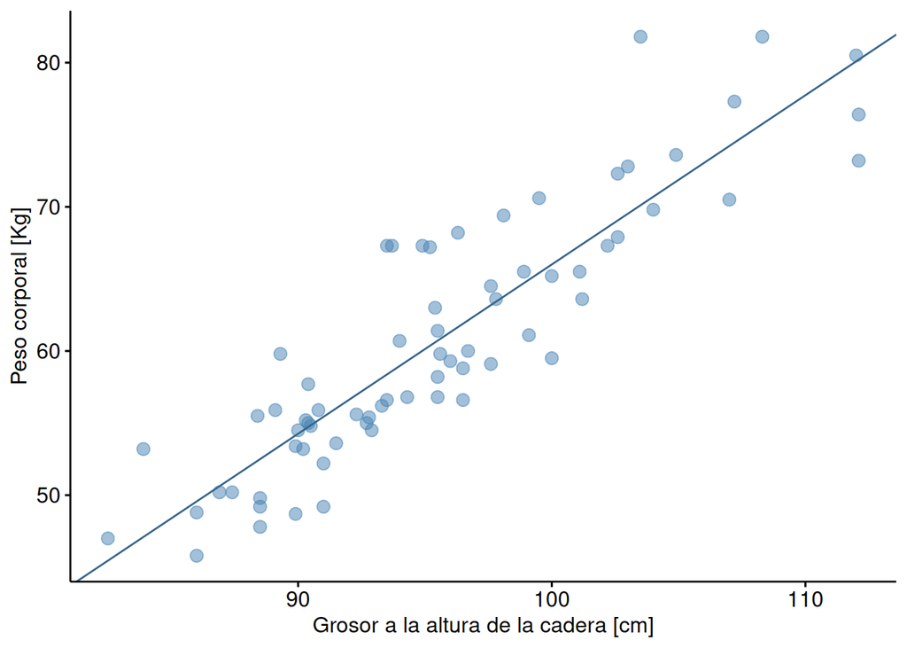

```r
g1 <- ggscatter(mujeres_seleccion , x = "Hip.Girth" , y = "Weight" ,
                  color = " steelblue " , fill = " steelblue1 " , alpha = 0.5 , size = 3,
                  ylab = " Peso corporal [Kg] " )
g1 <- g1 + geom_abline(intercept = coef(modelo_HG)[1] , slope = coef(modelo_HG)[2], color = " steelblue4 " )
g1 <- g1 + xlab ( bquote( "Grosor a la altura de la cadera [cm]"))
g1
```

Según el modelo de Regresión Lineal Simple construido, se rechaza la hipótesis nula $H_{0}: \beta_{1} = 0$, esto significa que la variable predictora escogida sobre el grosor a la altura de la cadera (Hip.Girth) tiene relación con la variable de salida Peso Corporal (Weight) como se ve en el gráfico anterior.

Con ello el modelo obtenido entonces es

```r
cat("\nModelo obtenido:\n")
```

```
##
## Modelo obtenido:
```

```r
print(modelo_HG[["coefficients"]])
```

```
## (Intercept)   Hip.Girth
##  -51.397747    1.173999
```

## Pregunta 6

Para seleccionar entre las variables aleatorias para predictoras se realizará una selección paso a paso:

```r
#Dataframe con variables aleatorias, peso, y variabble predictora elegida anteriormente
mujeres_filtrado2 <- mujeres_filtrado_con_peso |>
  select(all_of(names_raw),Weight,Hip.Girth)

#Se contruye el modelo con Peso y Hip.Girth
modelo <- lm(Weight ~ Hip.Girth, mujeres_filtrado2)
summary(modelo)
```

```
##
## Call:
## lm(formula = Weight ~ Hip.Girth, data = mujeres_filtrado2)
##
## Residuals:
##     Min      1Q  Median      3Q     Max
## -7.0076 -2.6557 -0.8502  2.2600 11.6888
##
## Coefficients:
##             Estimate Std. Error t value Pr(>|t|)
## (Intercept) -51.3978     6.9131  -7.435 2.32e-10 ***
## Hip.Girth     1.1740     0.0722  16.260  < 2e-16 ***
## ---
## Signif. codes:  0 '***' 0.001 '**' 0.01 '*' 0.05 '.' 0.1 ' ' 1
##
## Residual standard error: 4.026 on 68 degrees of freedom
## Multiple R-squared:  0.7954, Adjusted R-squared:  0.7924
## F-statistic: 264.4 on 1 and 68 DF,  p-value: < 2.2e-16
```

```r
#Modelo completo
completo_variables_aleatorias <- lm(Weight ~ Hip.Girth + ., mujeres_filtrado2)
summary(completo_variables_aleatorias)
```

```
##
## Call:
## lm(formula = Weight ~ Hip.Girth + ., data = mujeres_filtrado2)
##
## Residuals:
##     Min      1Q  Median      3Q     Max
## -4.7701 -1.2457 -0.2084  1.3029  6.0538
##
## Coefficients:
##                      Estimate Std. Error t value Pr(>|t|)
## (Intercept)         -78.58932    7.00560 -11.218 2.30e-16 ***
## Hip.Girth             0.64963    0.14177   4.582 2.38e-05 ***
## Chest.depth           0.34946    0.23474   1.489  0.14180
## Ankle.Minimum.Girth  -0.41699    0.41963  -0.994  0.32436
## Wrist.Minimum.Girth   1.75255    0.60149   2.914  0.00501 **
## Age                  -0.04178    0.04533  -0.922  0.36038
## Shoulder.Girth        0.20992    0.07598   2.763  0.00760 **
## Thigh.Girth          -0.14491    0.17294  -0.838  0.40541
## Calf.Maximum.Girth    0.72589    0.22424   3.237  0.00197 **
## Waist.Girth           0.23817    0.08288   2.874  0.00560 **
## ---
## Signif. codes:  0 '***' 0.001 '**' 0.01 '*' 0.05 '.' 0.1 ' ' 1
##
## Residual standard error: 2.595 on 60 degrees of freedom
## Multiple R-squared:  0.925,  Adjusted R-squared:  0.9138
## F-statistic: 82.26 on 9 and 60 DF,  p-value: < 2.2e-16
```

Ahora, buscaremos variables entre las generadas aleatoriamente anteriormente.

```r
paso <- add1(
  modelo,
  scope = completo_variables_aleatorias,
  test = "F",
  direction = "forward"
)

paso <- paso[order(paso$AIC), ]
print(paso)
```

```
## Single term additions
##
## Model:
## Weight ~ Hip.Girth
##                     Df Sum of Sq     RSS    AIC F value    Pr(>F)
## Shoulder.Girth       1    357.20  745.11 171.55 32.1194 3.326e-07 ***
## Waist.Girth          1    287.64  814.67 177.80 23.6563 7.301e-06 ***
## Calf.Maximum.Girth   1    271.13  831.19 179.21 21.8550 1.469e-05 ***
## Wrist.Minimum.Girth  1    213.55  888.77 183.89 16.0986 0.0001540 ***
## Chest.depth          1    190.89  911.43 185.66 14.0322 0.0003761 ***
## Ankle.Minimum.Girth  1    144.00  958.31 189.17 10.0680 0.0022781 **
## <none>                           1102.32 196.97
## Thigh.Girth          1      4.29 1098.02 198.69  0.2620 0.6104352
## Age                  1      0.48 1101.84 198.94  0.0292 0.8648651
## ---
## Signif. codes:  0 '***' 0.001 '**' 0.01 '*' 0.05 '.' 0.1 ' ' 1
```

Observamos que la variable que más reduce el valor AIC es Shoulder.Girth, o grosor de los hombros. Es por esto que es la variable que decidimos agregar primero.

```r
#Se agrega al modelo la variable Shoulder.Girth como predictora
modelo_a <- update(modelo, . ~ . + Shoulder.Girth)
paso <- add1(
  modelo_a,
  scope = completo_variables_aleatorias,
  test = "F",
  direction = "forward"
)

paso <- paso[order(paso$AIC), ]
print(paso)
```

```
## Single term additions
##
## Model:
## Weight ~ Hip.Girth + Shoulder.Girth
##                     Df Sum of Sq    RSS    AIC F value   Pr(>F)
## Calf.Maximum.Girth   1   132.279 612.83 159.87 14.2460 0.000346 ***
## Wrist.Minimum.Girth  1   109.948 635.16 162.38 11.4247 0.001221 **
## Waist.Girth          1    92.987 652.13 164.22  9.4110 0.003127 **
## Chest.depth          1    80.178 664.93 165.58  7.9583 0.006317 **
## Ankle.Minimum.Girth  1    41.778 703.33 169.51  3.9204 0.051876 .
## <none>                           745.11 171.55
## Thigh.Girth          1     0.709 744.40 173.49  0.0629 0.802797
## Age                  1     0.425 744.69 173.51  0.0377 0.846631
## ---
## Signif. codes:  0 '***' 0.001 '**' 0.01 '*' 0.05 '.' 0.1 ' ' 1
```

La variable que más reduce el AIC en este caso es Calf.Maximum.Girth que es el grosor promedio de la parte más ancha de ambas pantorrillas

```r
#Se agrega al modelo la variable Calf.Maximum.Girth como predictora
modelo_b <- update(modelo_a, . ~ . + Calf.Maximum.Girth)
paso <- add1(
  modelo_b,
  scope = completo_variables_aleatorias,
  test = "F",
  direction = "forward"
)

paso <- paso[order(paso$AIC), ]
print(paso)
```

```
## Single term additions
##
## Model:
## Weight ~ Hip.Girth + Shoulder.Girth + Calf.Maximum.Girth
##                     Df Sum of Sq    RSS    AIC F value    Pr(>F)
## Waist.Girth          1   115.783 497.05 147.21 15.1411 0.0002375 ***
## Chest.depth          1    56.961 555.87 155.04  6.6607 0.0121223 *
## Wrist.Minimum.Girth  1    51.241 561.59 155.76  5.9307 0.0176316 *
## Thigh.Girth          1    36.170 576.66 157.61  4.0770 0.0475989 *
## <none>                           612.83 159.87
## Ankle.Minimum.Girth  1     0.264 612.57 161.84  0.0280 0.8676779
## Age                  1     0.000 612.83 161.87  0.0000 0.9956312
## ---
## Signif. codes:  0 '***' 0.001 '**' 0.01 '*' 0.05 '.' 0.1 ' ' 1
```

Una vez agregada la variable Calf.Maximum.Girth como predictora, se identifica la variable que más reduce el AIC como Waist.Girth que es el grosor a la altura de la cintura.

```r
#Se agrega al modelo la variable Waist.Girth como predictora
modelo_c <- update(modelo_b, . ~ . + Waist.Girth)
paso <- add1(
  modelo_c,
  scope = completo_variables_aleatorias,
  test = "F",
  direction = "forward"
)

paso <- paso[order(paso$AIC), ]
print(paso)
```

```
## Single term additions
##
## Model:
## Weight ~ Hip.Girth + Shoulder.Girth + Calf.Maximum.Girth + Waist.Girth
##                     Df Sum of Sq    RSS    AIC F value  Pr(>F)
## Wrist.Minimum.Girth  1    65.719 431.33 139.29  9.7513 0.00269 **
## <none>                           497.05 147.21
## Thigh.Girth          1    12.577 484.47 147.42  1.6615 0.20204
## Chest.depth          1     9.100 487.95 147.92  1.1936 0.27871
## Age                  1     5.663 491.39 148.41  0.7376 0.39365
## Ankle.Minimum.Girth  1     3.135 493.92 148.77  0.4062 0.52619
## ---
## Signif. codes:  0 '***' 0.001 '**' 0.01 '*' 0.05 '.' 0.1 ' ' 1
```

Se identifica la variable Wrist.Minimum.Girth (Grosor promedio de la parte más delgada de ambas muñecas) como variable predictora y se agrega al modelo:

```r
#Se agrega al modelo la variable Wrist.Minimun.Girth como predictora
modelo_d <- update(modelo_c, . ~ . + Wrist.Minimum.Girth)
paso <- add1(
  modelo_d,
  scope = completo_variables_aleatorias,
  test = "F",
  direction = "forward"
)

paso <- paso[order(paso$AIC), ]
print(paso)
```

```
## Single term additions
##
## Model:
## Weight ~ Hip.Girth + Shoulder.Girth + Calf.Maximum.Girth + Waist.Girth +
##     Wrist.Minimum.Girth
##                     Df Sum of Sq    RSS    AIC F value Pr(>F)
## Chest.depth          1   13.2795 418.05 139.10  2.0012 0.1621
## <none>                           431.33 139.29
## Ankle.Minimum.Girth  1    4.6118 426.72 140.53  0.6809 0.4124
## Age                  1    3.4286 427.90 140.73  0.5048 0.4800
## Thigh.Girth          1    1.5816 429.75 141.03  0.2319 0.6318
```

```r
cat("\nModelo obtenido:\n")
```

```
##
## Modelo obtenido:
```

```r
print(modelo_d[["coefficients"]])
```

```
##         (Intercept)           Hip.Girth      Shoulder.Girth  Calf.Maximum.Girth
##         -78.3518630           0.5511712           0.2005918           0.5962957
##         Waist.Girth Wrist.Minimum.Girth
##           0.3066164           1.6028504
```

```r
summary(modelo_d)
```

```
##
## Call:
## lm(formula = Weight ~ Hip.Girth + Shoulder.Girth + Calf.Maximum.Girth +
##     Waist.Girth + Wrist.Minimum.Girth, data = mujeres_filtrado2)
##
## Residuals:
##     Min      1Q  Median      3Q     Max
## -4.5393 -1.6879 -0.1547  1.3578  5.8227
##
## Coefficients:
##                      Estimate Std. Error t value Pr(>|t|)
## (Intercept)         -78.35186    6.97703 -11.230  < 2e-16 ***
## Hip.Girth             0.55117    0.08228   6.699 6.26e-09 ***
## Shoulder.Girth        0.20059    0.07456   2.690 0.009096 **
## Calf.Maximum.Girth    0.59630    0.16721   3.566 0.000692 ***
## Waist.Girth           0.30662    0.06974   4.396 4.24e-05 ***
## Wrist.Minimum.Girth   1.60285    0.51329   3.123 0.002690 **
## ---
## Signif. codes:  0 '***' 0.001 '**' 0.01 '*' 0.05 '.' 0.1 ' ' 1
##
## Residual standard error: 2.596 on 64 degrees of freedom
## Multiple R-squared:  0.9199, Adjusted R-squared:  0.9137
## F-statistic: 147.1 on 5 and 64 DF,  p-value: < 2.2e-16
```

En donde el grosor a la altura de las caderas (Hip.Girth), el grosor de los hombros (Shoulder.Girth), el grosor promedio de la parte más ancha de ambas pantorrillas (Calf.Maximum.Girth), el grosor a la altura de la cintura (Waist.Girth) y grosor promedio de la parte más delgada de ambas muñecas (Wrist.Minimum.Girth) son las variables predictoras del peso corporal (Weight) de las mujeres.

## Pregunta 7

Para evaluar la confiabilidad del modelo obtenido, verificaremos las siguientes condiciones:

1. La variable de respuesta debe ser cuantitativa y continua, sin restricciones para su variabilidad: La variable de repuesta es el Peso, y se observa que es cuantitativa y continua, pues mide una magnitud física. Por lo mismo, no existen restricciones para su variabilidad.
2. Los predictores deben ser cuantitativos o dicotómicos (de ahí la necesidad de variables indicadoras para manejar más de dos niveles): Todos los predictores elegidos corresponden a variables que miden magnitudes física en cm, por lo que corresponden a variables cuantitativas.
3. Los predictores deben tener algún grado de variabilidad (su varianza no debe ser igual a cero). En otras palabras, no pueden ser constantes.

```r
apply(mujeres_random70[, c("Hip.Girth", "Shoulder.Girth", "Calf.Maximum.Girth" , "Waist.Girth","Wrist.Minimum.Girth")], 2, var)
```

```
##           Hip.Girth      Shoulder.Girth  Calf.Maximum.Girth         Waist.Girth
##          45.0651946          35.6949089           7.4865197          58.7802174
## Wrist.Minimum.Girth
##           0.6144596
```

Se verifica que todos los predictores presentan varianza estrictamente mayor que cero, por lo que ninguno de ellos es constante y se cumple el supuesto de variabilidad de los predictores.

4. Cada predictor debe estar relacionado linealmente con la respuesta.
5. La distribución de los residuos debe ser cercana a la normal centrada en cero.
6. La variabilidad de los residuos debe ser aproximadamente constante (homocedasticidad).

Para los puntos 4, 5 y 6 realizaremos gráficos de influencia y residuos comparados con el predictor.

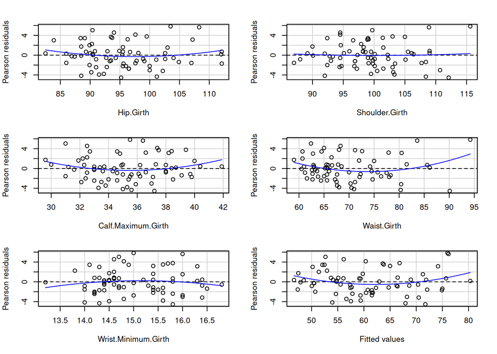

```
##                     Test stat Pr(>|Test stat|)
## Hip.Girth              1.1615          0.24982
## Shoulder.Girth         0.2763          0.78321
## Calf.Maximum.Girth     1.4989          0.13888
## Waist.Girth            2.2447          0.02830 *
## Wrist.Minimum.Girth   -0.8132          0.41918
## Tukey test             1.9327          0.05327 .
## ---
## Signif. codes:  0 '***' 0.001 '**' 0.01 '*' 0.05 '.' 0.1 ' ' 1
```

```r
residualPlots(modelo_d)
```

En los gráficos de residuos se observan leves curvaturas para algunas variables, particularmente Waist.Girth, lo que sugiere una posible desviación leve del supuesto de linealidad. Sin embargo, estas desviaciones no parecen severas. Asimismo, los residuos se encuentran aproximadamente centrados en cero y no presentan desviaciones extremas respecto a la normalidad. La dispersión de los residuos es relativamente constante, por lo que el supuesto de homocedasticidad se considera razonablemente satisfecho.

Se analizó el impacto de observaciones potencialmente influyentes mediante la distancia de Cook. Al excluir dichas observaciones y reajustar el modelo, se observa que los supuestos se mantienen razonablemente y las conclusiones generales no se alteran, por lo que el modelo original se considera adecuado.

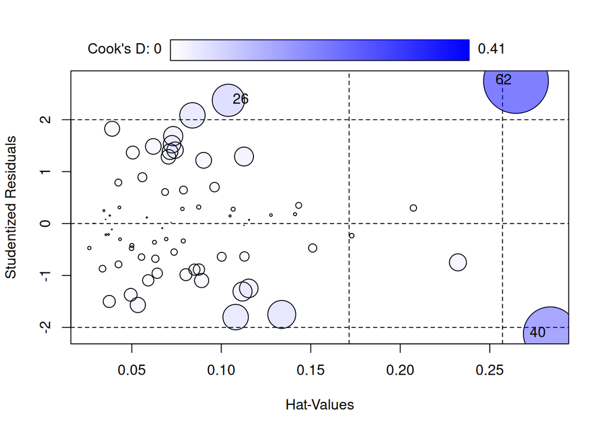

```
##      StudRes       Hat     CookD
## 26  2.373196 0.1039663 0.1015634
## 40 -2.121963 0.2838194 0.2819697
## 62  2.745966 0.2646608 0.4103773
```

```r
influencePlot(modelo_d)
```

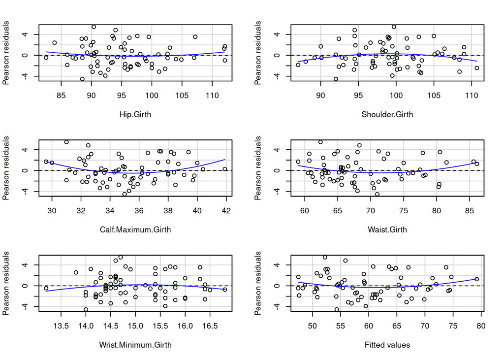

```
##                     Test stat Pr(>|Test stat|)
## Hip.Girth              0.8226          0.41398
## Shoulder.Girth        -1.3698          0.17587
## Calf.Maximum.Girth     2.0137          0.04854 *
## Waist.Girth            1.5954          0.11587
## Wrist.Minimum.Girth   -0.7902          0.43254
## Tukey test             1.3283          0.18409
## ---
## Signif. codes:  0 '***' 0.001 '**' 0.01 '*' 0.05 '.' 0.1 ' ' 1
```

```r
outliers <- c("62","40","26")

train <- mujeres_random70[ !rownames(mujeres_random70) %in% outliers, ]

modelo_train <- update(modelo_d, data = train)

residualPlots(modelo_train)
```

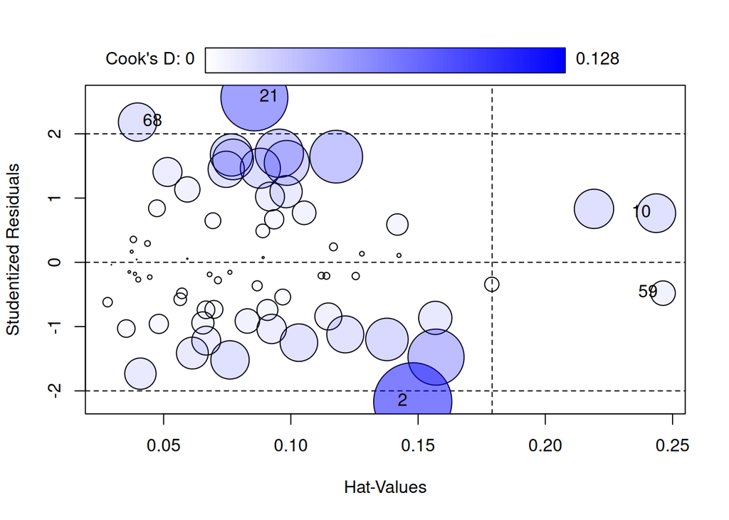

```
##       StudRes        Hat      CookD
## 2  -2.1693213 0.14790324 0.12834261
## 10  0.7653387 0.24359296 0.03165371
## 21  2.5658526 0.08567010 0.09418919
## 59 -0.4795897 0.24625806 0.01268449
## 68  2.1826157 0.03978129 0.03098200
```

```r
influencePlot(modelo_train)
```

Al comparar el modelo ajustado con la muestra completa y el modelo obtenido tras la exclusión temporal de las observaciones identificadas, se observa que:

En consecuencia, se concluye que el modelo es robusto frente a la presencia de estas observaciones y se decide mantener el modelo ajustado con la muestra completa, utilizando la exclusión únicamente con fines diagnósticos y no como criterio de selección final.

7. Los residuos deben ser independientes entre sí.

```r
durbinWatsonTest(modelo_d)
```

```
##  lag Autocorrelation D-W Statistic p-value
##    1      0.03545176      1.922128   0.776
##  Alternative hypothesis: rho != 0
```

Dado que el test de Durbin–Watson no resulta significativo (p > 0.05), no existe evidencia de autocorrelación entre los residuos, por lo que el supuesto de independencia se considera satisfecho.

8. No debe existir multicolinealidad. Esto significa que no deben darse relaciones lineales fuertes (coeficientes de correlación altos) entre dos o más predictores.

```r
vif(modelo_d)
```

```
##           Hip.Girth      Shoulder.Girth  Calf.Maximum.Girth         Waist.Girth
##            3.123244            2.031711            2.142879            2.927213
## Wrist.Minimum.Girth
##            1.657428
```

9. Las estimaciones de los coeficientes del modelo no debe estar alterados por unos pocas observaciones influyentes.

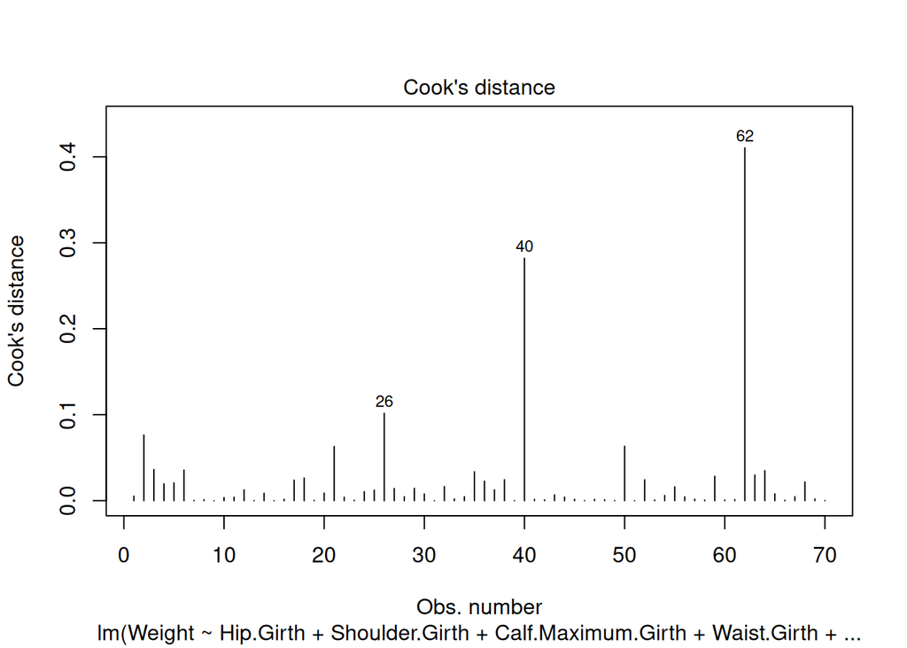

```r
plot(modelo_d, which = 4)
```

El análisis de la distancia de Cook no evidencia observaciones con influencia excesiva, ya que todos los valores se encuentran muy por debajo del umbral crítico. Por ello, el supuesto de ausencia de casos influyentes severos se considera satisfecho.

```r
summary(modelo_d)
```

```
##
## Call:
## lm(formula = Weight ~ Hip.Girth + Shoulder.Girth + Calf.Maximum.Girth +
##     Waist.Girth + Wrist.Minimum.Girth, data = mujeres_filtrado2)
##
## Residuals:
##     Min      1Q  Median      3Q     Max
## -4.5393 -1.6879 -0.1547  1.3578  5.8227
##
## Coefficients:
##                      Estimate Std. Error t value Pr(>|t|)
## (Intercept)         -78.35186    6.97703 -11.230  < 2e-16 ***
## Hip.Girth             0.55117    0.08228   6.699 6.26e-09 ***
## Shoulder.Girth        0.20059    0.07456   2.690 0.009096 **
## Calf.Maximum.Girth    0.59630    0.16721   3.566 0.000692 ***
## Waist.Girth           0.30662    0.06974   4.396 4.24e-05 ***
## Wrist.Minimum.Girth   1.60285    0.51329   3.123 0.002690 **
## ---
## Signif. codes:  0 '***' 0.001 '**' 0.01 '*' 0.05 '.' 0.1 ' ' 1
##
## Residual standard error: 2.596 on 64 degrees of freedom
## Multiple R-squared:  0.9199, Adjusted R-squared:  0.9137
## F-statistic: 147.1 on 5 and 64 DF,  p-value: < 2.2e-16
```

El modelo presenta un alto coeficiente de determinación ajustado ($R_{adj}^2$=0.9137), lo que indica que una proporción considerable de la variabilidad del peso corporal es explicada por los predictores incluidos.

## Pregunta 8 (Generalización)

```r
print(summary(modelo_d))
```

```
##
## Call:
## lm(formula = Weight ~ Hip.Girth + Shoulder.Girth + Calf.Maximum.Girth +
##     Waist.Girth + Wrist.Minimum.Girth, data = mujeres_filtrado2)
##
## Residuals:
##     Min      1Q  Median      3Q     Max
## -4.5393 -1.6879 -0.1547  1.3578  5.8227
##
## Coefficients:
##                      Estimate Std. Error t value Pr(>|t|)
## (Intercept)         -78.35186    6.97703 -11.230  < 2e-16 ***
## Hip.Girth             0.55117    0.08228   6.699 6.26e-09 ***
## Shoulder.Girth        0.20059    0.07456   2.690 0.009096 **
## Calf.Maximum.Girth    0.59630    0.16721   3.566 0.000692 ***
## Waist.Girth           0.30662    0.06974   4.396 4.24e-05 ***
## Wrist.Minimum.Girth   1.60285    0.51329   3.123 0.002690 **
## ---
## Signif. codes:  0 '***' 0.001 '**' 0.01 '*' 0.05 '.' 0.1 ' ' 1
##
## Residual standard error: 2.596 on 64 degrees of freedom
## Multiple R-squared:  0.9199, Adjusted R-squared:  0.9137
## F-statistic: 147.1 on 5 and 64 DF,  p-value: < 2.2e-16
```

```r
rmse_modelo_70 <- sqrt(mean(resid(modelo_d)**2))
cat("RMSE para el conjunto de entrenamiento:",rmse_modelo_70, "\n")
```

```
## RMSE para el conjunto de entrenamiento: 2.482311
```

```r
predicciones <- predict(modelo_d, mujeres_random_30)

error <- mujeres_random_30[["Weight"]] - predicciones

rmse_prueba <- sqrt(mean(error **2))
cat("RMSE para el conjunto de prueba:",rmse_prueba)
```

```
## RMSE para el conjunto de prueba: 2.641784
```

Los valores de RMSE obtenidos para el conjunto de entrenamiento y de prueba son del mismo orden de magnitud, lo que sugiere un desempeño predictivo consistente y ausencia de sobreajuste relevante.

## Conclusión

El modelo final presenta un alto coeficiente de determinación ajustado, lo que indica que una proporción considerable de la variabilidad del peso corporal es explicada por las variables incluidas. El análisis de los supuestos del modelo muestra que, en general, se cumplen razonablemente las condiciones de linealidad, normalidad de los residuos, homocedasticidad, independencia y ausencia de multicolinealidad severa. Si bien se identificaron algunas observaciones con mayor influencia relativa, estas no alteran de forma sustantiva el ajuste ni las conclusiones del modelo, por lo que se decidió mantener el modelo ajustado con la muestra completa.

Finalmente, al evaluar el poder predictivo del modelo en datos no utilizados para su construcción, se obtuvieron valores de error de predicción del mismo orden de magnitud que los observados en el conjunto de entrenamiento, lo que sugiere un desempeño predictivo consistente y una adecuada capacidad de generalización dentro del contexto del estudio.

En conjunto, los resultados indican que el modelo obtenido constituye una aproximación adecuada y robusta para describir la relación entre el peso corporal y las medidas antropométricas consideradas en la población analizada, bajo los supuestos del modelo de regresión lineal múltiple.